# The What, Why, and How of Uncertainty Visualisation

Harriet Mason

# Walktober

## What is walktober?

My department (Monash EBS) had a walkathon in October where we all competed to see how many steps we could walk each day

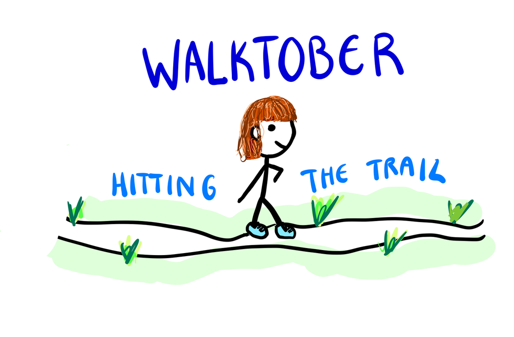

## Data quality angel

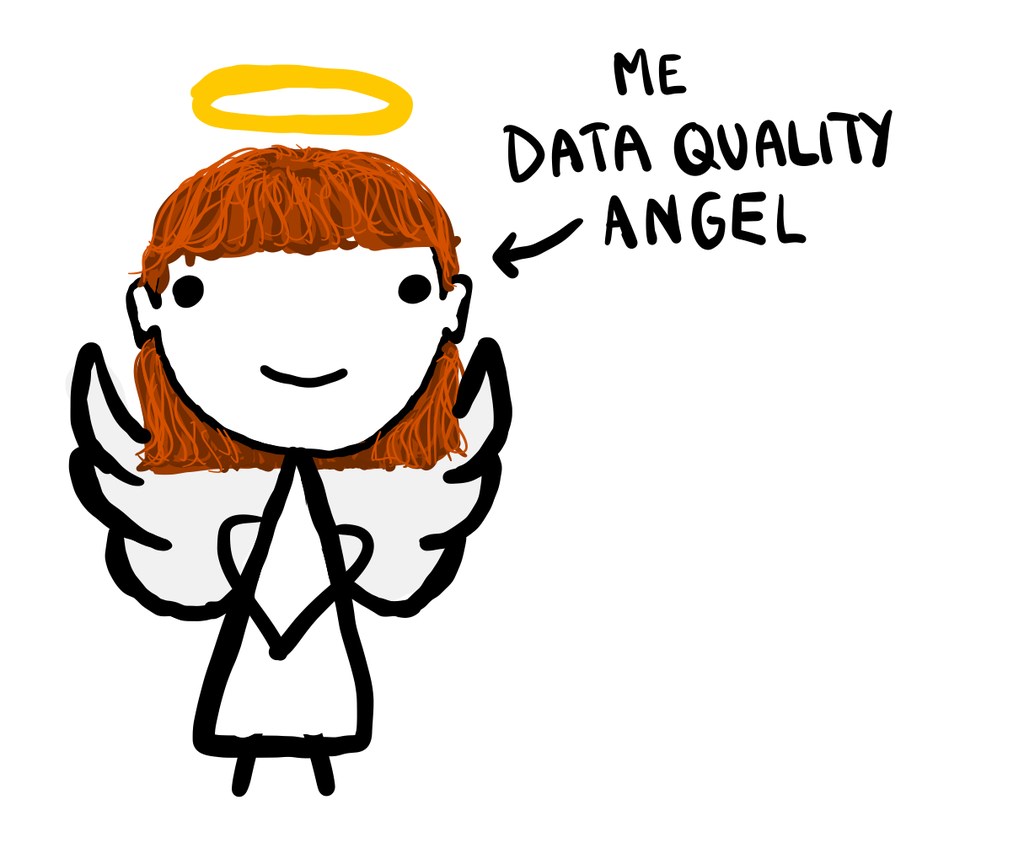

Before the competition started, I searched up the most accurate and cost effective pedometer

## Pedometer = bad

- It turns out, pedometers are wildly inaccurate

[figure not shown]

## Data quality demons

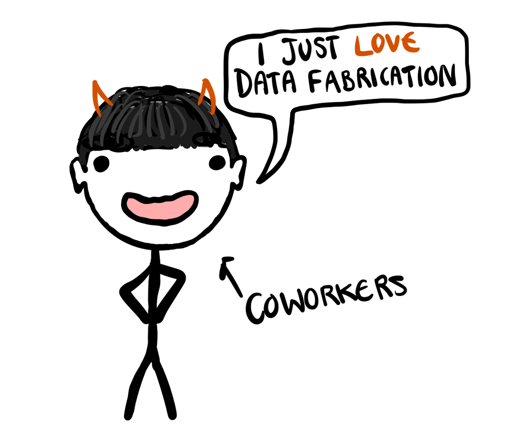

- We conducted a survey after walktober, to see if we could quantify the pedometer error
- It turns out I was the ONLY person concerned about data quality
- Turns out the measurement error was the least of my worries

## Survey response

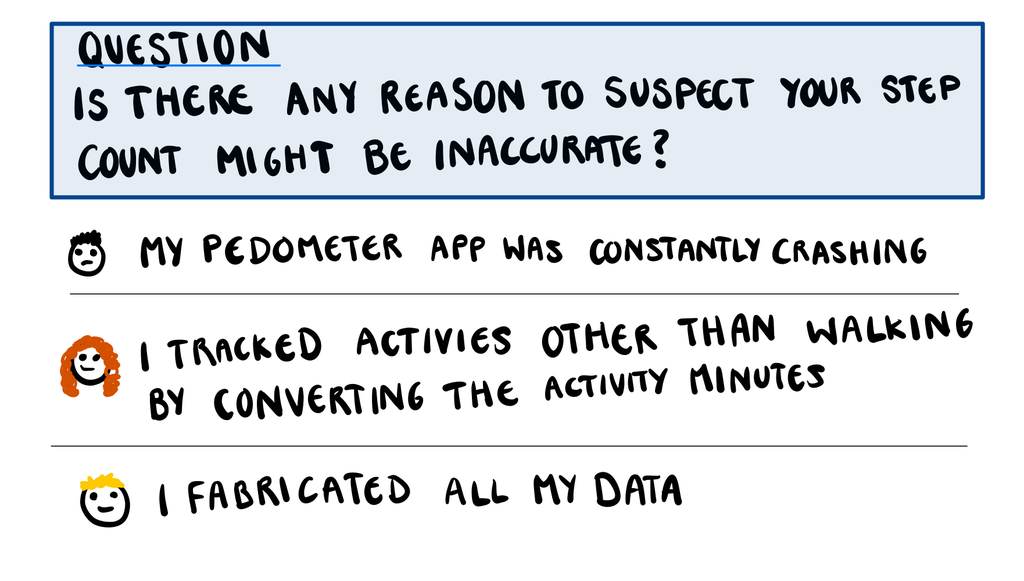

## The visualisation challenge

Our department decides to do a visualisation challenge of the walktober data

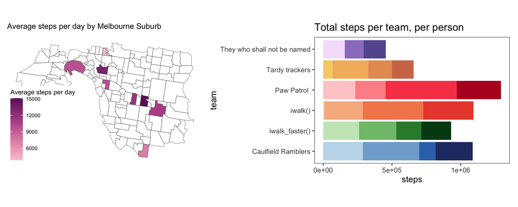

## …Should I include that uncertainty?

- This seems like it is going to be a lot of work
  - But I did all that reading about pedometers!!!
- Also, other people will get mad at me:
  - Failing to include it is akin to fraud! (Hullman 2020; Manski 2020)
  - Conveys the legitimacy (or illegitimacy) of conclusions (Kale et al. 2018; Griethe and Schumann 2006)
  - Communicate confidence (Correll et al. 2018; Boukhelifa et al. 2017)
  - Communicate validity (Hullman 2020; Griethe and Schumann 2006)
  - It should guide, qualify or soften judgements (Wilkinson 2005)
- **Increase transparency**

## Signal Modulation

- **Signal modulation**: statistical validity translates to perceptual ease
  - The higher the variance on an estimate, the harder that estimate is to extract from the plot

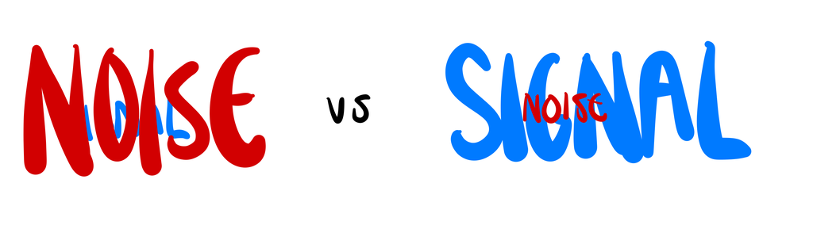

## A visual hypothesis test

Our visualisation should have behaviour similar to

- a hypothesis test (Correll et al. 2018; MacEachren 1992) or
- a Bayesian posterior probability (Kim et al. 2019)

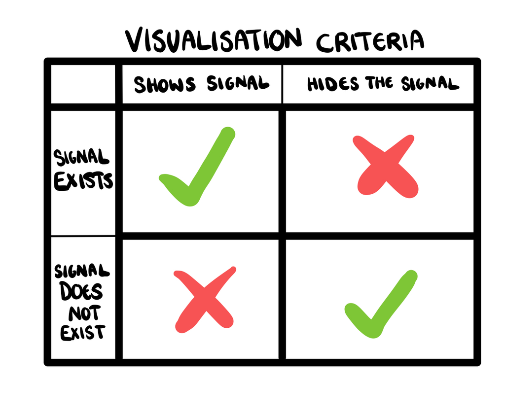

## OK, Fine!

Those properties sound pretty good., so we will make an uncertain version of these plots.

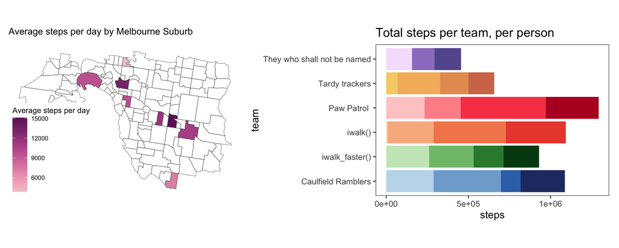

## Overview

Making uncertain versions of these plots is the focus of this talk

- Part 1: What is uncertainty?
- Part 2: What is a visualisation?
- Part 3: How to (safely) make uncertainty visualisations in `ggdibbler`

Other episodes of this series include (cut for time)

- Part 4: Metrics and convergence for visual statistics
- Part 5: Testing how well these plots perform signal modulation

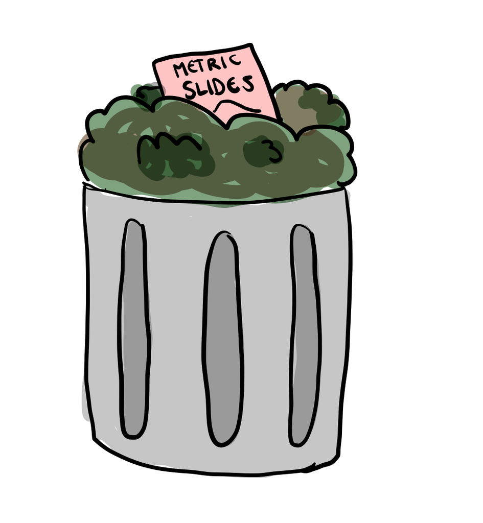

# Part 1: What is uncertainty?

## The word association Olympics

- No definition, just a word salad
- Can nobody tell me what uncertainty *IS*?
- How can you visualise something you can’t even define?

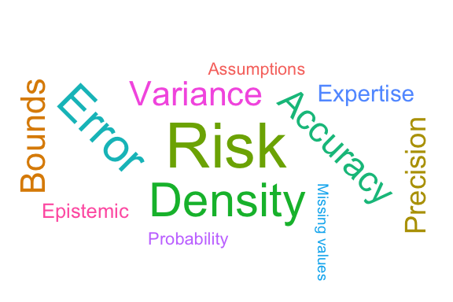

## If you are me…

You decide the entire field is fake and not worth working on

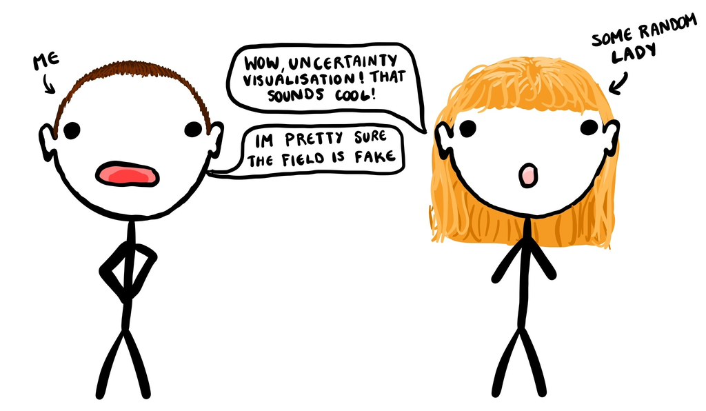

## But…

Your PhD is externally funded with a set topic

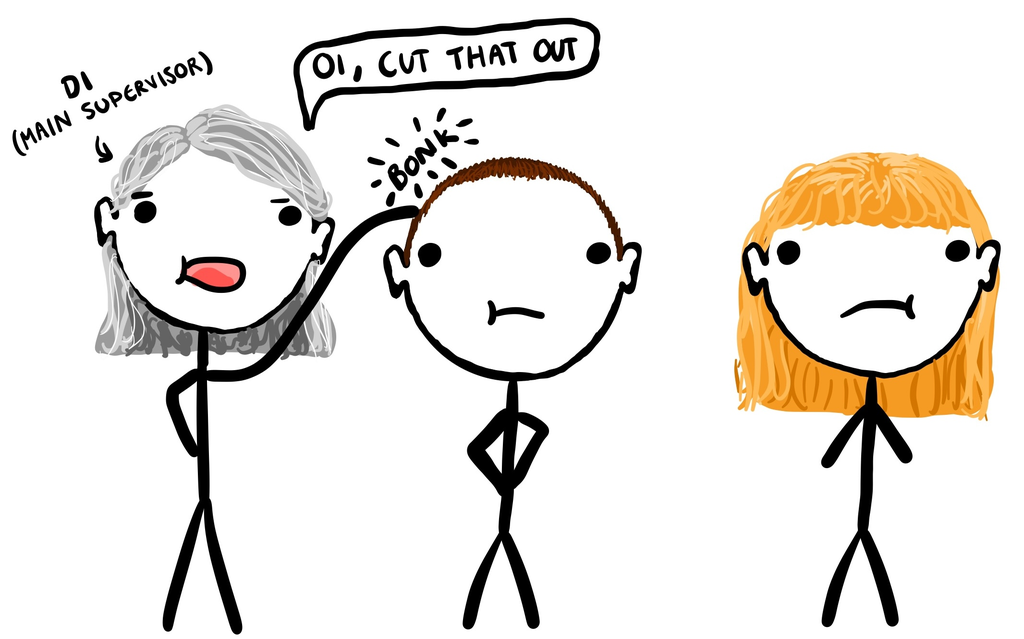

## So you take another approach

- Instead of defining what uncertainty **IS**…
- Maybe we can look at where uncertainty **ISN’T?**
- To do that, we need to take a look back into the past…

## Statistics philosophy?

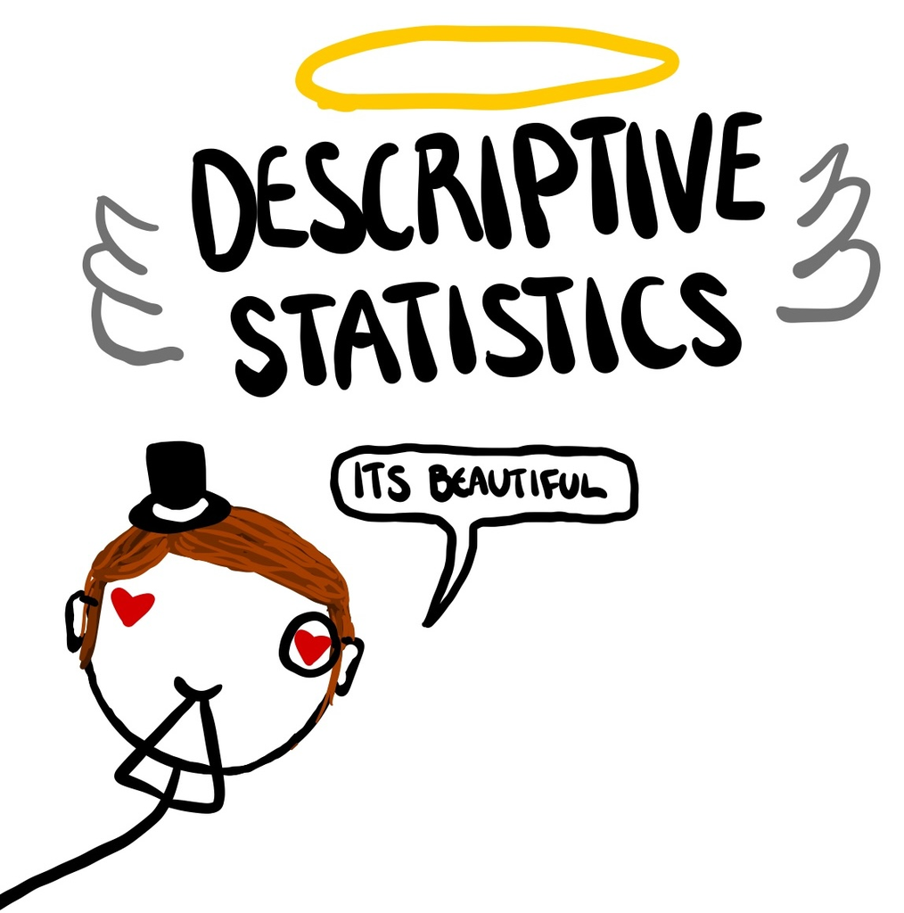

- In nineteenth-century England, positivism was all the rage
  - Posivitists do not believe in referencing the “unknown”, as it is *bad science* (Otsuka 2023)
  - Therefore they only do descriptive statistics
  - Descriptive statistics summarise, they report things as they are without looking beyond the data

## Statistics philosophy?

- What’s the alternative? **Inference**
  - discussions about future values
  - population parameters
  - new observations
- Requires a key assumption: *The uniformity of nature* (Otsuka 2023)
  - Assume the observations we have are similar to the ones we do not have
  - Violating this assumption creates uncertainty

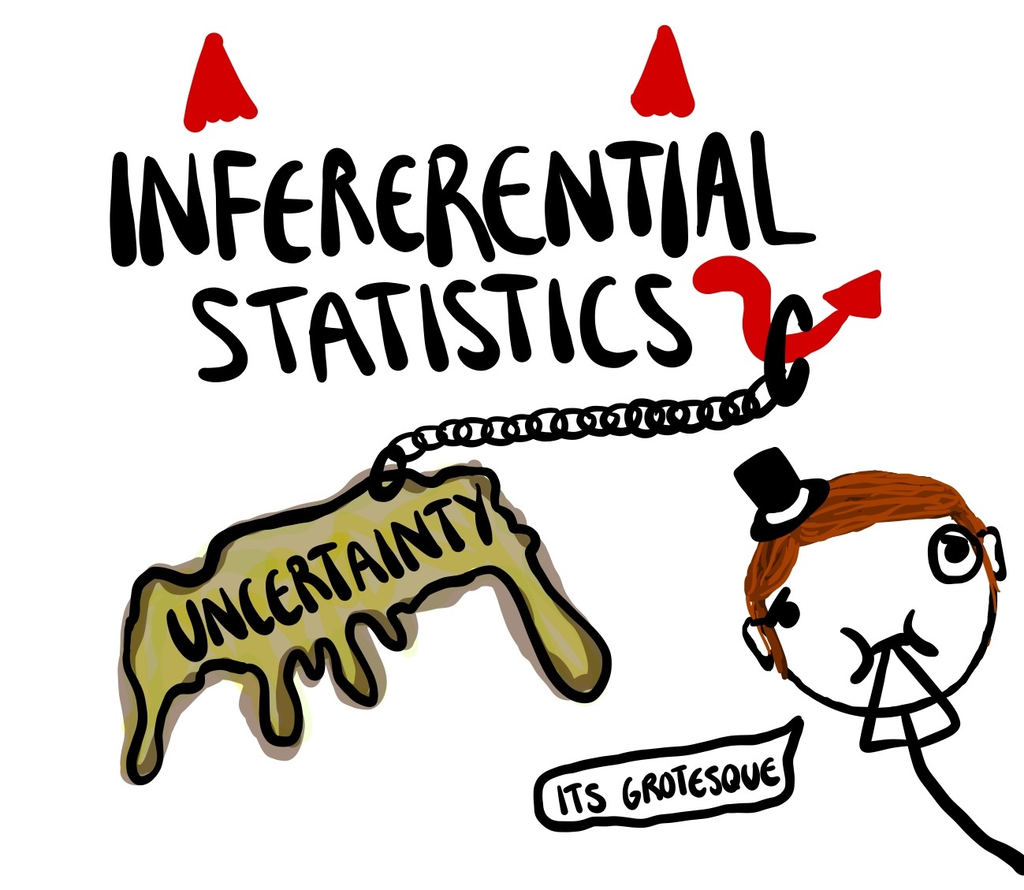

## Yes. And?

- This gives us a pretty workable understanding of inference
- Uncertainty is a product of inference
  - Without inference we have no uncertainty
    - (*We need something to be uncertain about*)
  - We cannot have inference without uncertainty
    - (*If we look beyond our data, we can never know for sure*)
- Quantifying uncertainty requires estimating the effect of the violations on our inference

## Example: missing values

- That is kind of abstract (sorry)
- To give a concrete example, lets look at *missing values*
  - They are not really, in and of themselves “uncertain”
  - They can *create* uncertainty when we perform inference
- Missing values before inference are “unquantified uncertainty”
  - I like to think of it as “potential uncertainty” like “potential energy”

## Example: missing values

- We van visualise missing values with `naniar`(Tierney and Cook 2023)
- What is the point of the missing values?
  - There is nothing uncertain here
  - The data is *missing not at random (MNAR)*, so what?
- Unquantified uncertainty = assumption checks
  - Assumptions require a model

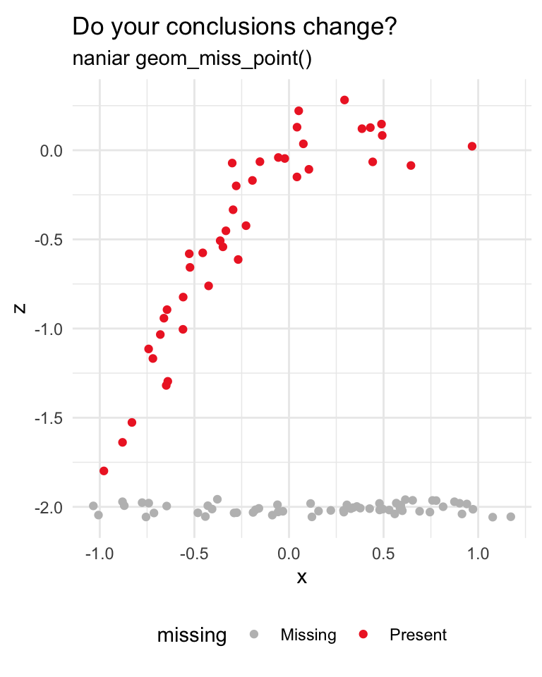

## Example: missing values

- Implicitly in visualisation, you might be drawing this smoothed line in your head
  - Visualising missing values won’t magically change the estimate or confidence intervals
- For uncertainty to act as “noise” and perform **signal modulation**, it needs to be **quantified**

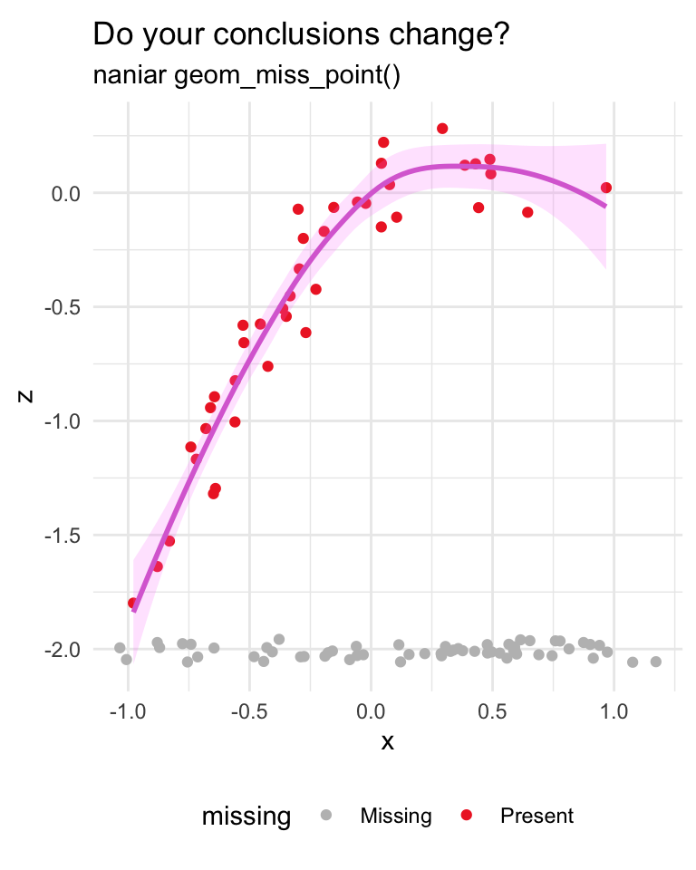

## Source of uncertainty

- Only two points where inference can occur
  1. The data itself (i.e. we are visualising estimates)
  2. The conclusions we draw from the plot (i.e. visual inference)
- Visualisation is used for exploratory data analysis (EDA)
- **Uncertainty can only come from the data**

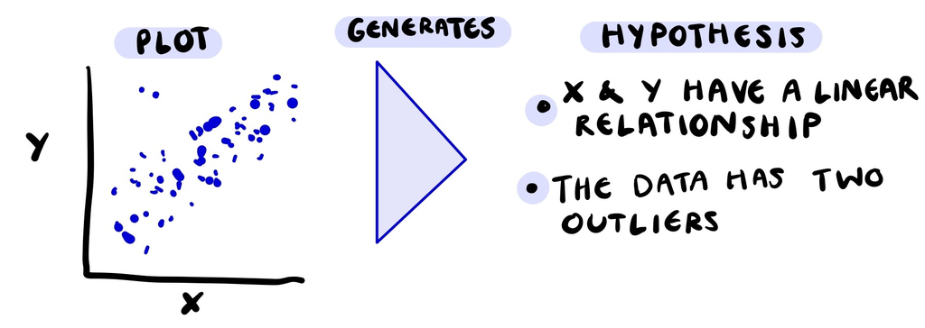

## To summarise

- At some point in our analysis we perform *inference* and created *estimates*
- We *quantify* the uncertainty in these estimates by representing them as *probability distributions*
  - “Anything worth doing is worth doing poorly” - G. K. Chesterton
- A table of probability distributions is a *random matrix*

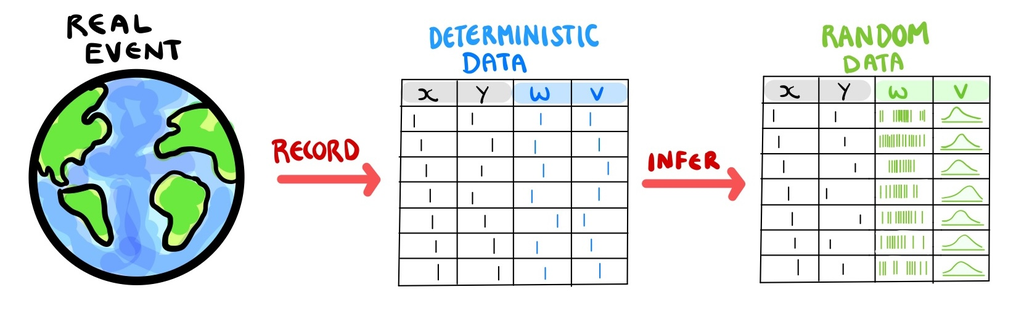

## You see this kind of data constantly

Often our data is…

- Unavailable
  - anonymised data, measurement error, etc.
- Non-deterministic
  - bounded data, estimated values, etc.
- Theoretical
  - latent variables, calculations from theory, etc.
- Abstract
  - based on expert opinion or credibility

## Make this data using distributional

- In practice we can make random matricies with `distributional`
- Our walktober examples are truncated normal distributions
  - The “prior inference” comes from measurement error
    - What is my *true* step count, not the *recorded* step count

```
# A tibble: 4 × 3
                steps_dist team    name
                    <dist> <chr>   <chr>
1 N(23679, 4633687)[0,Inf) iwalk() A
2 N(18322, 2774223)[0,Inf) iwalk() A
3   N(24562, 5e+06)[0,Inf) iwalk() A
4 N(26128, 5642050)[0,Inf) iwalk() A
```

# Part 2: What is a visualisation?

## Uhh I know what a visualisation is…

It’s a picture

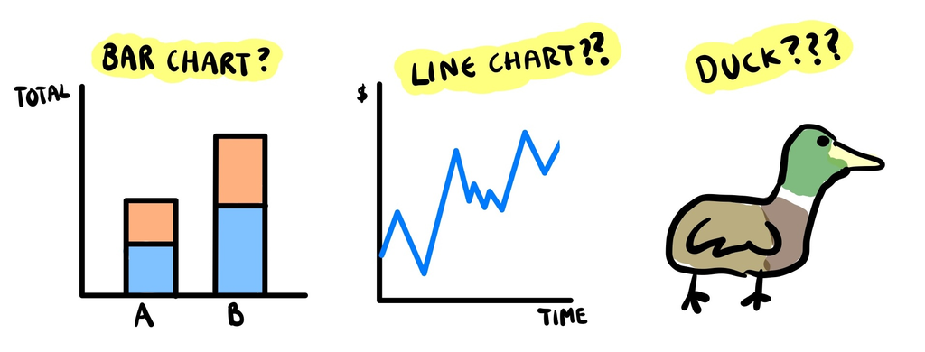

## It’s not that simple

- What is the essence a visualisation? What is it trying to do?
- Now, allow me to butcher an argument presented by Bartonicek et al. (2025)

[figure not shown]

## A graphic is a map between data and visual representation

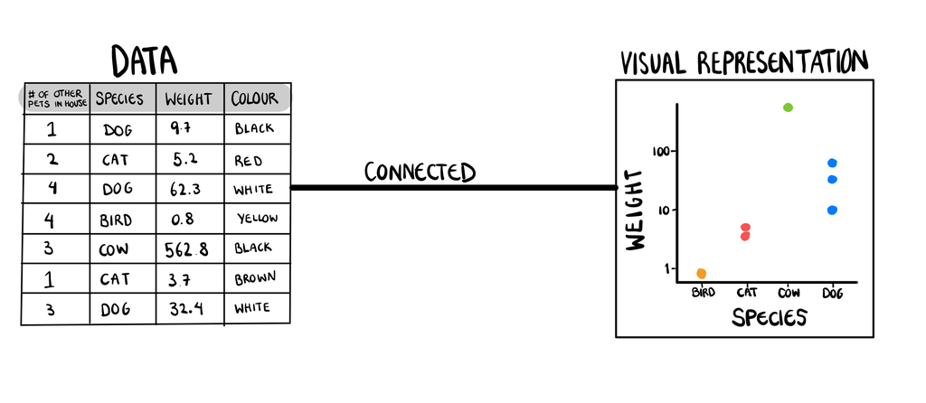

## But what happens when you break that link?

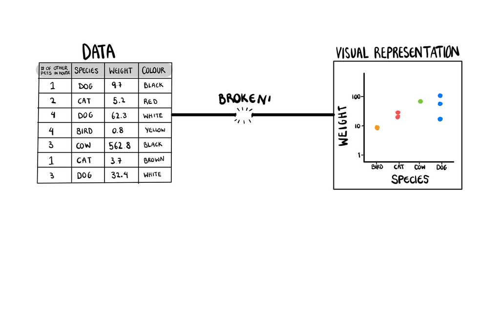

## Analogy to “The Treachery of Images”

These are not data visualisations, there is no data

- These are drawings

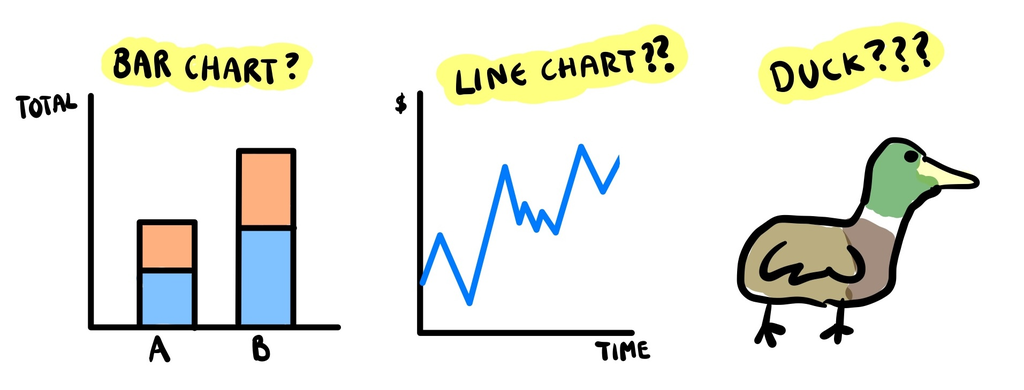

## Take it one step further

Visualisations are continuous functions

- A small change in our data, should result in a small change to our visualisation
- A lot of perception research is implicitly based on this assumption
  - e.g. checking if colour pallets warp the space, etc.

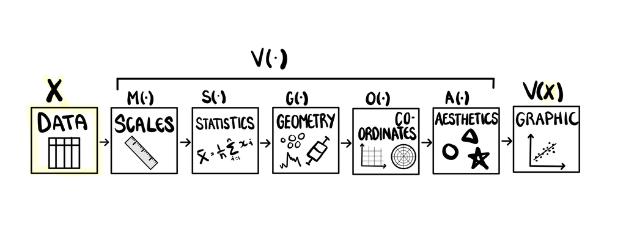

## Wait a second….

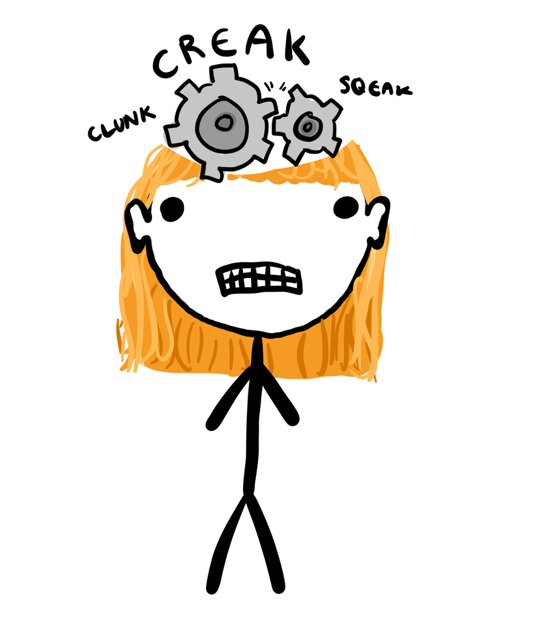

## Wait a second….

If uncertainty visualisations have a *random matrix input*…

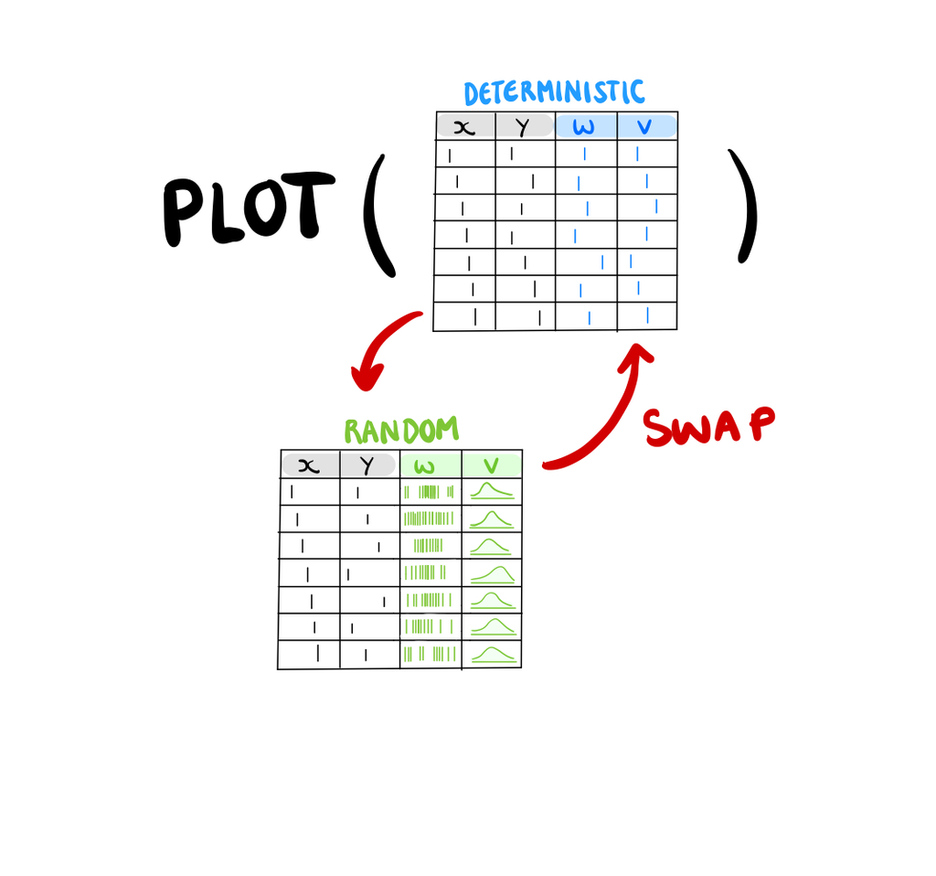

## Wait a second….

… and a visualisation is a continuous function…

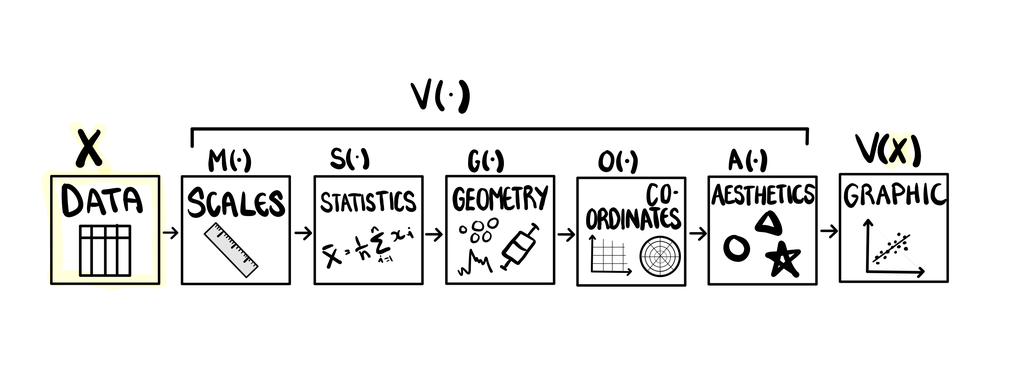

## Wait a second….

…then shouldn’t they follow continuous mapping theorem? (Mann and Wald 1943)?

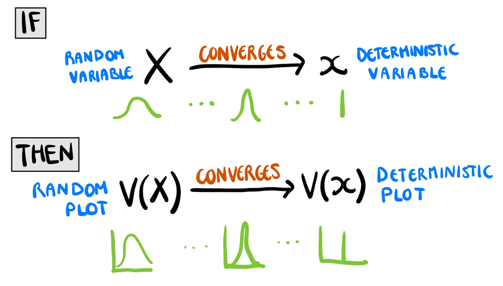

## Properties of V(X)

Visualisations should adhere to continuous mapping theorem

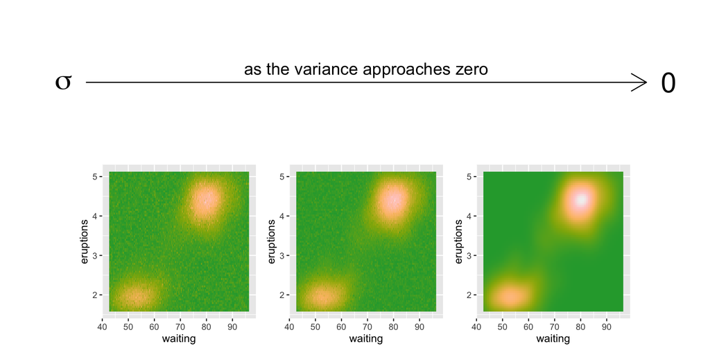

## Is this ANOTHER metric?

- Didn’t we already have that signal noise thing?
- It’s just our original goal in a suit
- Data resolution is intrinsicly linked to variance (Meng 2014)
  - If your resolution is too high, you will get uncertainty
- In visualisation, this interpretation is very literal
  - e.g. points become area reducing the resolution
- Precision loss makes the “nosier” values harder to extract
  - i.e. signal modulation

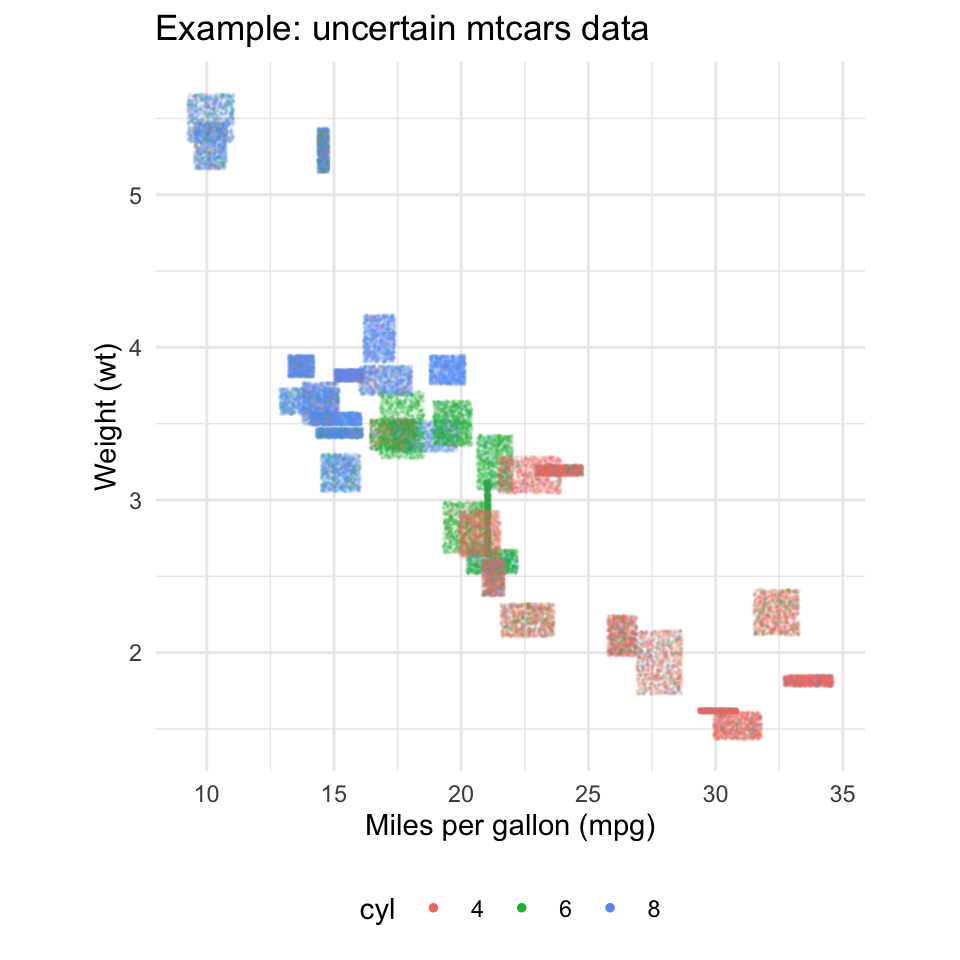

## Hold up…

- Doesn’t convergence require a definition of distance?
  - Yes
- It’s too long for this talk, but we did do it